# Celebrities and vaccinations

### Load the required libraries for research

```r
#install.packages("data.table")
library(tidyverse)
library(data.table)
library(dplyr)
library(plotly)
```

### Read vaccination data for all countries

```r
data_vaccination <- read.csv("country_vaccinations.csv")

data_vaccination
```

| country | iso_code | date | total_vaccinations | people_vaccinated | people_fully_vaccinated | daily_vaccinations_raw | daily_vaccinations | total_vaccinations_per_hundred | people_vaccinated_per_hundred | people_fully_vaccinated_per_hundred | daily_vaccinations_per_million | vaccines | source_name | source_website |
| --- | --- | --- | --- | --- | --- | --- | --- | --- | --- | --- | --- | --- | --- | --- |
| Afghanistan | AFG | 2021-02-22 | 0 | 0 | NA | NA | NA | 0.00 | 0.00 | NA | NA | Oxford/AstraZeneca | Government of Afghanistan | https://reliefweb.int/report/afghanistan/afghanistan-strategic-situation-report-covid-19-no-95-22-april-2021 |
| Afghanistan | AFG | 2021-02-23 | NA | NA | NA | NA | 1367 | NA | NA | NA | 35 | Oxford/AstraZeneca | Government of Afghanistan | https://reliefweb.int/report/afghanistan/afghanistan-strategic-situation-report-covid-19-no-95-22-april-2021 |
| Afghanistan | AFG | 2021-02-24 | NA | NA | NA | NA | 1367 | NA | NA | NA | 35 | Oxford/AstraZeneca | Government of Afghanistan | https://reliefweb.int/report/afghanistan/afghanistan-strategic-situation-report-covid-19-no-95-22-april-2021 |
| Afghanistan | AFG | 2021-02-25 | NA | NA | NA | NA | 1367 | NA | NA | NA | 35 | Oxford/AstraZeneca | Government of Afghanistan | https://reliefweb.int/report/afghanistan/afghanistan-strategic-situation-report-covid-19-no-95-22-april-2021 |
| Afghanistan | AFG | 2021-02-26 | NA | NA | NA | NA | 1367 | NA | NA | NA | 35 | Oxford/AstraZeneca | Government of Afghanistan | https://reliefweb.int/report/afghanistan/afghanistan-strategic-situation-report-covid-19-no-95-22-april-2021 |
| Afghanistan | AFG | 2021-02-27 | NA | NA | NA | NA | 1367 | NA | NA | NA | 35 | Oxford/AstraZeneca | Government of Afghanistan | https://reliefweb.int/report/afghanistan/afghanistan-strategic-situation-report-covid-19-no-95-22-april-2021 |
| Afghanistan | AFG | 2021-02-28 | 8200 | 8200 | NA | NA | 1367 | 0.02 | 0.02 | NA | 35 | Oxford/AstraZeneca | Government of Afghanistan | https://reliefweb.int/report/afghanistan/afghanistan-strategic-situation-report-covid-19-no-95-22-april-2021 |
| Afghanistan | AFG | 2021-03-01 | NA | NA | NA | NA | 1580 | NA | NA | NA | 41 | Oxford/AstraZeneca | Government of Afghanistan | https://reliefweb.int/report/afghanistan/afghanistan-strategic-situation-report-covid-19-no-95-22-april-2021 |
| Afghanistan | AFG | 2021-03-02 | NA | NA | NA | NA | 1794 | NA | NA | NA | 46 | Oxford/AstraZeneca | Government of Afghanistan | https://reliefweb.int/report/afghanistan/afghanistan-strategic-situation-report-covid-19-no-95-22-april-2021 |
| Afghanistan | AFG | 2021-03-03 | NA | NA | NA | NA | 2008 | NA | NA | NA | 52 | Oxford/AstraZeneca | Government of Afghanistan | https://reliefweb.int/report/afghanistan/afghanistan-strategic-situation-report-covid-19-no-95-22-april-2021 |

[output cut: 990 more lines]

### Replace `NA` for numeric columns

```r
data_vaccination <- data_vaccination  %>%
  mutate(across(where(is.numeric), ~ ifelse(is.na(.), 0, .)))
data_vaccination
```

| country | iso_code | date | total_vaccinations | people_vaccinated | people_fully_vaccinated | daily_vaccinations_raw | daily_vaccinations | total_vaccinations_per_hundred | people_vaccinated_per_hundred | people_fully_vaccinated_per_hundred | daily_vaccinations_per_million | vaccines | source_name | source_website |
| --- | --- | --- | --- | --- | --- | --- | --- | --- | --- | --- | --- | --- | --- | --- |
| Afghanistan | AFG | 2021-02-22 | 0 | 0 | 0 | 0 | 0 | 0.00 | 0.00 | 0.00 | 0 | Oxford/AstraZeneca | Government of Afghanistan | https://reliefweb.int/report/afghanistan/afghanistan-strategic-situation-report-covid-19-no-95-22-april-2021 |
| Afghanistan | AFG | 2021-02-23 | 0 | 0 | 0 | 0 | 1367 | 0.00 | 0.00 | 0.00 | 35 | Oxford/AstraZeneca | Government of Afghanistan | https://reliefweb.int/report/afghanistan/afghanistan-strategic-situation-report-covid-19-no-95-22-april-2021 |
| Afghanistan | AFG | 2021-02-24 | 0 | 0 | 0 | 0 | 1367 | 0.00 | 0.00 | 0.00 | 35 | Oxford/AstraZeneca | Government of Afghanistan | https://reliefweb.int/report/afghanistan/afghanistan-strategic-situation-report-covid-19-no-95-22-april-2021 |
| Afghanistan | AFG | 2021-02-25 | 0 | 0 | 0 | 0 | 1367 | 0.00 | 0.00 | 0.00 | 35 | Oxford/AstraZeneca | Government of Afghanistan | https://reliefweb.int/report/afghanistan/afghanistan-strategic-situation-report-covid-19-no-95-22-april-2021 |
| Afghanistan | AFG | 2021-02-26 | 0 | 0 | 0 | 0 | 1367 | 0.00 | 0.00 | 0.00 | 35 | Oxford/AstraZeneca | Government of Afghanistan | https://reliefweb.int/report/afghanistan/afghanistan-strategic-situation-report-covid-19-no-95-22-april-2021 |
| Afghanistan | AFG | 2021-02-27 | 0 | 0 | 0 | 0 | 1367 | 0.00 | 0.00 | 0.00 | 35 | Oxford/AstraZeneca | Government of Afghanistan | https://reliefweb.int/report/afghanistan/afghanistan-strategic-situation-report-covid-19-no-95-22-april-2021 |
| Afghanistan | AFG | 2021-02-28 | 8200 | 8200 | 0 | 0 | 1367 | 0.02 | 0.02 | 0.00 | 35 | Oxford/AstraZeneca | Government of Afghanistan | https://reliefweb.int/report/afghanistan/afghanistan-strategic-situation-report-covid-19-no-95-22-april-2021 |
| Afghanistan | AFG | 2021-03-01 | 0 | 0 | 0 | 0 | 1580 | 0.00 | 0.00 | 0.00 | 41 | Oxford/AstraZeneca | Government of Afghanistan | https://reliefweb.int/report/afghanistan/afghanistan-strategic-situation-report-covid-19-no-95-22-april-2021 |
| Afghanistan | AFG | 2021-03-02 | 0 | 0 | 0 | 0 | 1794 | 0.00 | 0.00 | 0.00 | 46 | Oxford/AstraZeneca | Government of Afghanistan | https://reliefweb.int/report/afghanistan/afghanistan-strategic-situation-report-covid-19-no-95-22-april-2021 |
| Afghanistan | AFG | 2021-03-03 | 0 | 0 | 0 | 0 | 2008 | 0.00 | 0.00 | 0.00 | 52 | Oxford/AstraZeneca | Government of Afghanistan | https://reliefweb.int/report/afghanistan/afghanistan-strategic-situation-report-covid-19-no-95-22-april-2021 |

[output cut: 990 more lines]

### Reading data on the vaccination of famous Britons

```r
famous_british_vaccinated <- read.csv("famous_british_people_vaccinated_2021.csv")

famous_british_vaccinated <- famous_british_vaccinated[!duplicated(famous_british_vaccinated$date), ]

famous_british_vaccinated
```

|  | name | date |
| --- | --- | --- |
| 1 | Joan Collins | 2021-01-10 |
| 2 | Sir David Attenborough | 2021-01-12 |
| 3 | Sir Tom Jones | 2021-01-30 |
| 4 | Alex George | 2021-01-06 |
| 5 | Judi Dench | 2021-01-14 |
| 6 | Patrick Stewart | 2021-01-22 |
| 7 | Anthony Daniels | 2021-02-03 |
| 8 | Anthony Hopkins | 2021-01-28 |
| 9 | Sir Elton John | 2021-02-10 |
| 11 | Ozzy Osbourne | 2021-02-12 |

[output cut: 9 more lines]

### Reading data on the vaccination of famous Americans

```r
famous_us_vaccinated <- read.csv("famous_us_people_vaccinated_2021.csv")

famous_us_vaccinated <- famous_us_vaccinated[!duplicated(famous_us_vaccinated$date), ]

famous_us_vaccinated
```

|  | name | date |
| --- | --- | --- |
| 1 | Martha Stewart | 2021-01-11 |
| 2 | Willie Nelson | 2021-01-13 |
| 3 | Steve Martin | 2021-01-17 |
| 5 | Arnold Schwarzenegger | 2021-01-20 |
| 6 | Samuel L. Jackson | 2021-01-23 |
| 7 | Sean Penn | 2021-01-26 |
| 8 | Harrison Ford | 2021-01-25 |
| 9 | Jane Fonda | 2021-02-01 |
| 11 | Paul Stanley | 2021-02-16 |
| 12 | Alice Cooper | 2021-02-09 |

[output cut: 13 more lines]

### Clear unnecessary data and add days of the year

#### Withdrawal of vaccinated Britons

```r
british_vaccinated <- data_vaccination[ data_vaccination$country == "England", ]
british_vaccinated.daily <- select(british_vaccinated, daily_vaccinations_per_million, date)
british_vaccinated.daily$days <- c(1:length(british_vaccinated.daily$date))
british_vaccinated.daily$date <- as.Date(british_vaccinated$date)
british_vaccinated.daily
```

|  | daily_vaccinations_per_million | date | days |
| --- | --- | --- | --- |
| 3819 | 0 | 2021-01-03 | 1 |
| 3820 | 2894 | 2021-01-04 | 2 |
| 3821 | 2894 | 2021-01-05 | 3 |
| 3822 | 2894 | 2021-01-06 | 4 |
| 3823 | 2894 | 2021-01-07 | 5 |
| 3824 | 2894 | 2021-01-08 | 6 |
| 3825 | 2894 | 2021-01-09 | 7 |
| 3826 | 2894 | 2021-01-10 | 8 |
| 3827 | 2837 | 2021-01-11 | 9 |
| 3828 | 2900 | 2021-01-12 | 10 |

[output cut: 104 more lines]

#### Withdrawal of vaccinated Americans

```r
us_vaccinated <- data_vaccination[ data_vaccination$country == "United States", ]
us_vaccinated.daily <- select(us_vaccinated, daily_vaccinations_per_million, date)

us_vaccinated.daily$date <- as.Date(us_vaccinated.daily$date)
us_vaccinated.daily <- us_vaccinated.daily[us_vaccinated.daily$date >= "2021-01-01", ]

us_vaccinated.daily$days <- c(1:length(us_vaccinated.daily$date))
us_vaccinated.daily
```

|  | daily_vaccinations_per_million | date | days |
| --- | --- | --- | --- |
| 13726 | 904 | 2021-01-01 | 1 |
| 13727 | 974 | 2021-01-02 | 2 |
| 13728 | 1007 | 2021-01-03 | 3 |
| 13729 | 1041 | 2021-01-04 | 4 |
| 13730 | 1015 | 2021-01-05 | 5 |
| 13731 | 1073 | 2021-01-06 | 6 |
| 13732 | 1131 | 2021-01-07 | 7 |
| 13733 | 1256 | 2021-01-08 | 8 |
| 13734 | 1379 | 2021-01-09 | 9 |
| 13735 | 1634 | 2021-01-10 | 10 |

[output cut: 107 more lines]

### Adding all vaccinated Britons by week

```r
#require(tidyverse)

british_vaccinated.weekly <- british_vaccinated.daily %>%
  group_by(week = week(date)) %>%
  summarise_if(is.numeric, sum)

british_vaccinated.weekly <- british_vaccinated.weekly %>%
  rename(
    weekly_vaccinations_per_million = daily_vaccinations_per_million
    )

british_vaccinated.weekly$days <- NULL
british_vaccinated.weekly
```

| week | weekly_vaccinations_per_million |
| --- | --- |
| 1 | 8682 |
| 2 | 20430 |
| 3 | 28725 |
| 4 | 38158 |
| 5 | 41783 |
| 6 | 44265 |
| 7 | 42309 |
| 8 | 38470 |
| 9 | 39739 |
| 10 | 36088 |

[output cut: 7 more lines]

### Adding all vaccinated Americans by week

```r
us_vaccinated.weekly <- us_vaccinated.daily %>%
  group_by(week = week(date)) %>%
  summarise_if(is.numeric, sum)

us_vaccinated.weekly <- us_vaccinated.weekly %>%
  rename(
    weekly_vaccinations_per_million = daily_vaccinations_per_million
    )

us_vaccinated.weekly$days <- NULL
us_vaccinated.weekly
```

| week | weekly_vaccinations_per_million |
| --- | --- |
| 1 | 6014 |
| 2 | 11332 |
| 3 | 17412 |
| 4 | 22353 |
| 5 | 27207 |
| 6 | 29475 |
| 7 | 34691 |
| 8 | 31394 |
| 9 | 36506 |
| 10 | 44641 |

[output cut: 7 more lines]

### Grouping of Britons by days of the year

```r
famous_british_vaccinated <- famous_british_vaccinated %>%
  group_by(week = week(date)) %>%
  group_by(days = yday(date))

famous_british_vaccinated
```

| name | date | week | days |
| --- | --- | --- | --- |
| Joan Collins | 2021-01-10 | 2 | 10 |
| Sir David Attenborough | 2021-01-12 | 2 | 12 |
| Sir Tom Jones | 2021-01-30 | 5 | 30 |
| Alex George | 2021-01-06 | 1 | 6 |
| Judi Dench | 2021-01-14 | 3 | 14 |
| Patrick Stewart | 2021-01-22 | 4 | 22 |
| Anthony Daniels | 2021-02-03 | 5 | 34 |
| Anthony Hopkins | 2021-01-28 | 5 | 28 |
| Sir Elton John | 2021-02-10 | 6 | 41 |
| Ozzy Osbourne | 2021-02-12 | 7 | 43 |

[output cut: 9 more lines]

### Grouping of Americans by days of the year

```r
famous_us_vaccinated <- famous_us_vaccinated %>%
  group_by(week = week(date)) %>%
  group_by(days = yday(date))

famous_us_vaccinated
```

| name | date | week | days |
| --- | --- | --- | --- |
| Martha Stewart | 2021-01-11 | 2 | 11 |
| Willie Nelson | 2021-01-13 | 2 | 13 |
| Steve Martin | 2021-01-17 | 3 | 17 |
| Arnold Schwarzenegger | 2021-01-20 | 3 | 20 |
| Samuel L. Jackson | 2021-01-23 | 4 | 23 |
| Sean Penn | 2021-01-26 | 4 | 26 |
| Harrison Ford | 2021-01-25 | 4 | 25 |
| Jane Fonda | 2021-02-01 | 5 | 32 |
| Paul Stanley | 2021-02-16 | 7 | 47 |
| Alice Cooper | 2021-02-09 | 6 | 40 |

[output cut: 13 more lines]

#### Because we have information that famous Britons were vaccinated, but we do not have information about what would have happened if they had not been vaccinated. Therefore, the impact of vaccination of famous people in the same country is inappropriate. To do this, we will take a +- similar country for vaccinations to Britain, such as the United States. And compare the famous Britons on the Americans and the famous Americans on the Britons

## Americans and famous Britons

#### By weeks

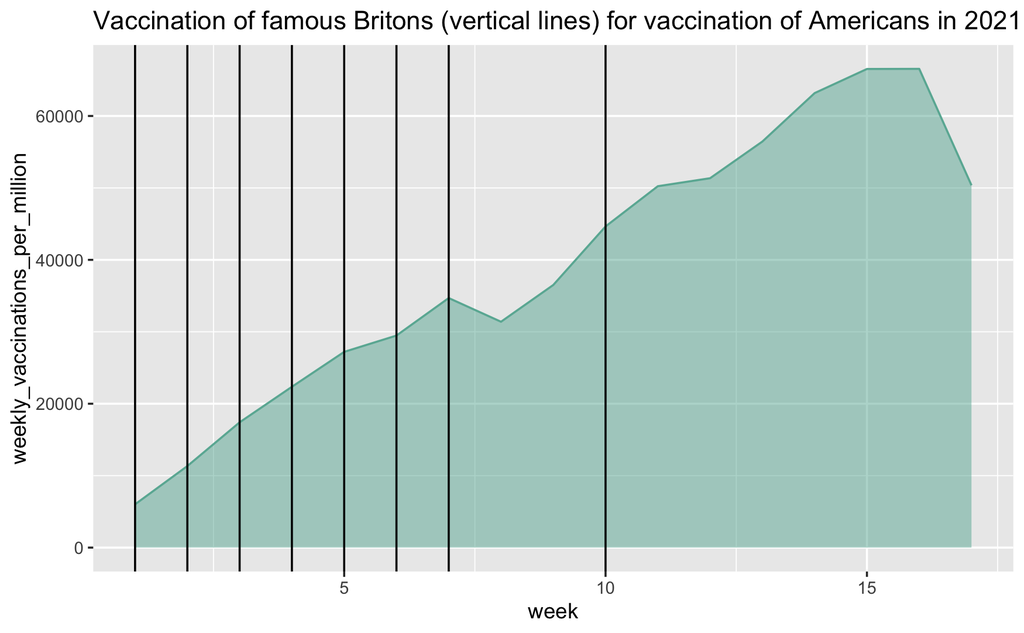

```r
p <- us_vaccinated.weekly %>%
  ggplot( aes(x=week, y=weekly_vaccinations_per_million)) +
    geom_area(fill="#69b3a2", alpha=0.5) +
    geom_line(color="#69b3a2") +
    geom_vline(xintercept = famous_british_vaccinated$week) +
    ggtitle("Vaccination of famous Britons (vertical lines) for vaccination of Americans in 2021")

p
```

#### By days

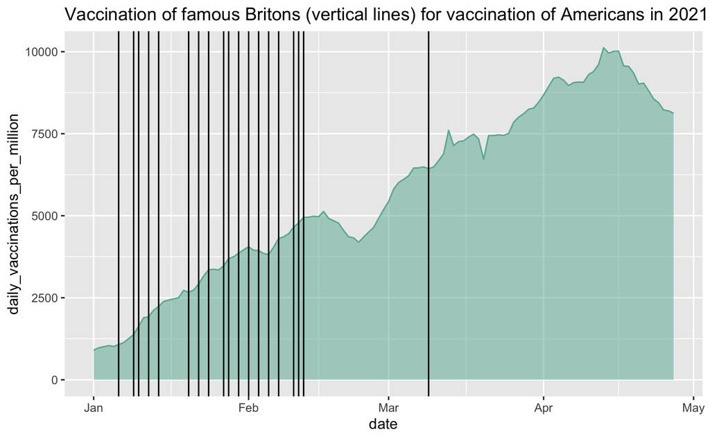

```r
famous_british_vaccinated$date <- as.Date(famous_british_vaccinated$date)

p <- us_vaccinated.daily %>%
  ggplot( aes(x=date, y=daily_vaccinations_per_million)) +
    geom_area(fill="#69b3a2", alpha=0.5) +
    geom_line(color="#69b3a2") +
    geom_vline(xintercept = famous_british_vaccinated$date) +
    ggtitle("Vaccination of famous Britons (vertical lines) for vaccination of Americans in 2021")
p
```

## Britons and famous Americans

#### By weeks

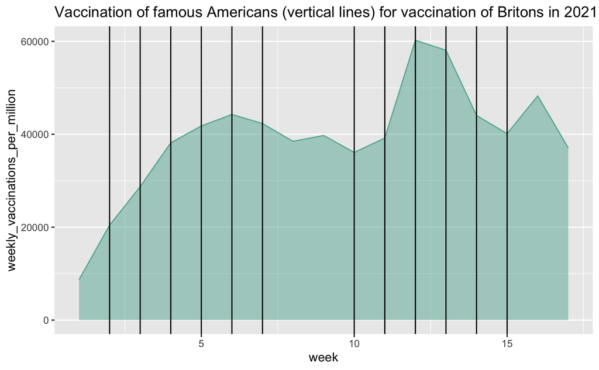

```r
p <- british_vaccinated.weekly %>%
  ggplot( aes(x=week, y=weekly_vaccinations_per_million)) +
    geom_area(fill="#69b3a2", alpha=0.5) +
    geom_line(color="#69b3a2") +
    geom_vline(xintercept = famous_us_vaccinated$week) +
    ggtitle("Vaccination of famous Americans (vertical lines) for vaccination of Britons in 2021")

p
```

#### By days

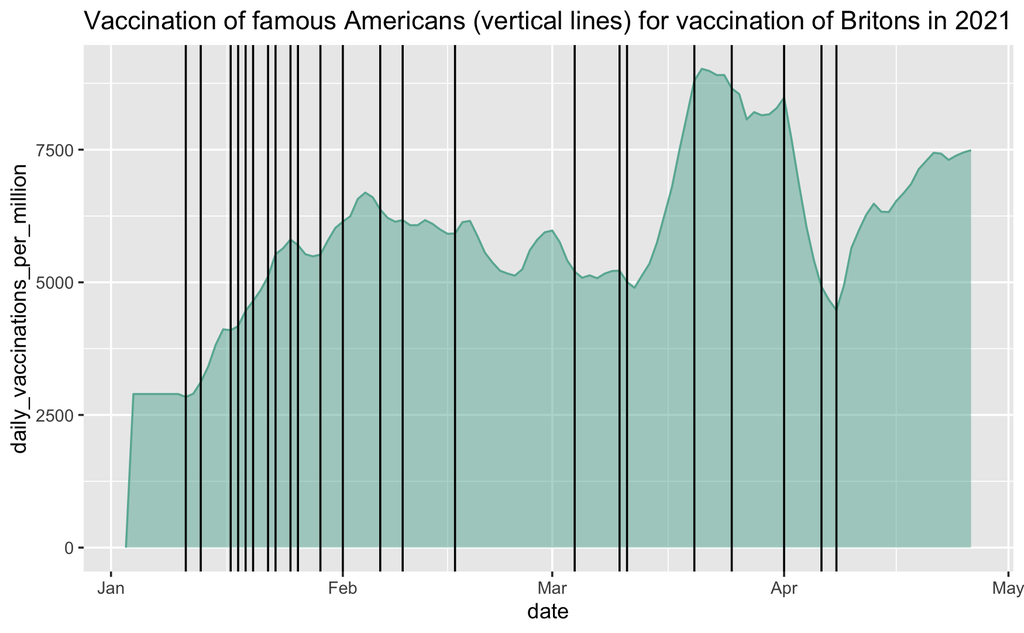

```r
famous_us_vaccinated$date <- as.Date(famous_us_vaccinated$date)

p <- british_vaccinated.daily %>%
  ggplot( aes(x=date, y=daily_vaccinations_per_million)) +
    geom_area(fill="#69b3a2", alpha=0.5) +
    geom_line(color="#69b3a2") +
    geom_vline(xintercept = famous_us_vaccinated$date) +
    ggtitle("Vaccination of famous Americans (vertical lines) for vaccination of Britons in 2021")
p
```

#### We did this on the usual information, but now let’s look at the percentage change by days and weeks to better assess the percentage dependence not on the number, but on the change of increase or decrease in vaccinations. To do this, simply count the growth rates of both countries

### Calculating growth rates for Britain (weekly)

```r
growth_rate_british.weekly <- british_vaccinated.weekly %>%
  # first sort by year
  arrange(week) %>%
  mutate(Diff_week = week - lag(week),  # Difference in week time
         Diff_growth = weekly_vaccinations_per_million - lag(weekly_vaccinations_per_million), # Difference in vaccination between weeks
         Rate_percent = (Diff_growth / Diff_week)/weekly_vaccinations_per_million * 100) # growth rate in percent

growth_rate_british.weekly <- growth_rate_british.weekly  %>%
  mutate(across(where(is.numeric), ~ ifelse(is.na(.), 0, .)))

growth_rate_british.weekly
```

| week | weekly_vaccinations_per_million | Diff_week | Diff_growth | Rate_percent |
| --- | --- | --- | --- | --- |
| 1 | 8682 | 0 | 0 | 0.000000 |
| 2 | 20430 | 1 | 11748 | 57.503671 |
| 3 | 28725 | 1 | 8295 | 28.877285 |
| 4 | 38158 | 1 | 9433 | 24.720897 |
| 5 | 41783 | 1 | 3625 | 8.675777 |
| 6 | 44265 | 1 | 2482 | 5.607139 |
| 7 | 42309 | 1 | -1956 | -4.623130 |
| 8 | 38470 | 1 | -3839 | -9.979205 |
| 9 | 39739 | 1 | 1269 | 3.193337 |
| 10 | 36088 | 1 | -3651 | -10.116936 |

[output cut: 7 more lines]

### Calculating growth rates for the US (weekly)

```r
growth_rate_us.weekly <- us_vaccinated.weekly %>%
  # first sort by year
  arrange(week) %>%
  mutate(Diff_week = week - lag(week),  # Difference in week time
         Diff_growth = weekly_vaccinations_per_million - lag(weekly_vaccinations_per_million), # Difference in vaccination between weeks
         Rate_percent = (Diff_growth / Diff_week)/weekly_vaccinations_per_million * 100) # growth rate in percent

growth_rate_us.weekly <- growth_rate_us.weekly  %>%
  mutate(across(where(is.numeric), ~ ifelse(is.na(.), 0, .)))

growth_rate_us.weekly
```

| week | weekly_vaccinations_per_million | Diff_week | Diff_growth | Rate_percent |
| --- | --- | --- | --- | --- |
| 1 | 6014 | 0 | 0 | 0.00000000 |
| 2 | 11332 | 1 | 5318 | 46.92905048 |
| 3 | 17412 | 1 | 6080 | 34.91844705 |
| 4 | 22353 | 1 | 4941 | 22.10441551 |
| 5 | 27207 | 1 | 4854 | 17.84099680 |
| 6 | 29475 | 1 | 2268 | 7.69465649 |
| 7 | 34691 | 1 | 5216 | 15.03560001 |
| 8 | 31394 | 1 | -3297 | -10.50200675 |
| 9 | 36506 | 1 | 5112 | 14.00317756 |
| 10 | 44641 | 1 | 8135 | 18.22315808 |

[output cut: 7 more lines]

### Calculating growth rates for Britain (daily)

```r
growth_rate_british.daily <- british_vaccinated.daily %>%
  # first sort by year
  arrange(date) %>%
  mutate(Diff_day = days - lag(days),  # Difference in week time
         Diff_growth = daily_vaccinations_per_million - lag(daily_vaccinations_per_million), # Difference in vaccination between weeks
         Rate_percent = (Diff_growth / Diff_day)/daily_vaccinations_per_million * 100) # growth rate in percent

growth_rate_british.daily <- growth_rate_british.daily  %>%
  mutate(across(where(is.numeric), ~ ifelse(is.na(.), 0, .)))

growth_rate_british.daily
```

| daily_vaccinations_per_million | date | days | Diff_day | Diff_growth | Rate_percent |
| --- | --- | --- | --- | --- | --- |
| 0 | 2021-01-03 | 1 | 0 | 0 | 0.00000000 |
| 2894 | 2021-01-04 | 2 | 1 | 2894 | 100.00000000 |
| 2894 | 2021-01-05 | 3 | 1 | 0 | 0.00000000 |
| 2894 | 2021-01-06 | 4 | 1 | 0 | 0.00000000 |
| 2894 | 2021-01-07 | 5 | 1 | 0 | 0.00000000 |
| 2894 | 2021-01-08 | 6 | 1 | 0 | 0.00000000 |
| 2894 | 2021-01-09 | 7 | 1 | 0 | 0.00000000 |
| 2894 | 2021-01-10 | 8 | 1 | 0 | 0.00000000 |
| 2837 | 2021-01-11 | 9 | 1 | -57 | -2.00916461 |
| 2900 | 2021-01-12 | 10 | 1 | 63 | 2.17241379 |

[output cut: 104 more lines]

### Calculating growth rates for the US (daily)

```r
growth_rate_us.daily <- us_vaccinated.daily %>%
  # first sort by year
  arrange(date) %>%
  mutate(Diff_day = days - lag(days),  # Difference in week time
         Diff_growth = daily_vaccinations_per_million - lag(daily_vaccinations_per_million), # Difference in vaccination between weeks
         Rate_percent = (Diff_growth / Diff_day)/daily_vaccinations_per_million * 100) # growth rate in percent

growth_rate_us.daily <- growth_rate_us.daily  %>%
  mutate(across(where(is.numeric), ~ ifelse(is.na(.), 0, .)))

growth_rate_us.daily
```

| daily_vaccinations_per_million | date | days | Diff_day | Diff_growth | Rate_percent |
| --- | --- | --- | --- | --- | --- |
| 904 | 2021-01-01 | 1 | 0 | 0 | 0.00000000 |
| 974 | 2021-01-02 | 2 | 1 | 70 | 7.18685832 |
| 1007 | 2021-01-03 | 3 | 1 | 33 | 3.27706058 |
| 1041 | 2021-01-04 | 4 | 1 | 34 | 3.26609030 |
| 1015 | 2021-01-05 | 5 | 1 | -26 | -2.56157635 |
| 1073 | 2021-01-06 | 6 | 1 | 58 | 5.40540541 |
| 1131 | 2021-01-07 | 7 | 1 | 58 | 5.12820513 |
| 1256 | 2021-01-08 | 8 | 1 | 125 | 9.95222930 |
| 1379 | 2021-01-09 | 9 | 1 | 123 | 8.91950689 |
| 1634 | 2021-01-10 | 10 | 1 | 255 | 15.60587515 |

[output cut: 107 more lines]

### Plotting growth rates for Britain and famous Americans (weekly)

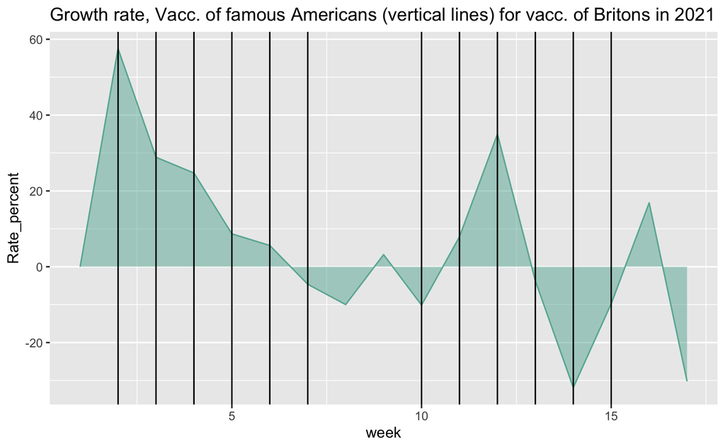

```r
p.growth_british.weekly <- growth_rate_british.weekly %>%
  ggplot( aes(x=week, y=Rate_percent)) +
    geom_area(fill="#69b3a2", alpha=0.5) +
    geom_line(color="#69b3a2") +
    geom_vline(xintercept = famous_us_vaccinated$week) +
    ggtitle("Growth rate, Vacc. of famous Americans (vertical lines) for vacc. of Britons in 2021")

p.growth_british.weekly
```

### Plotting growth rates for the US and famous Britons (weekly)

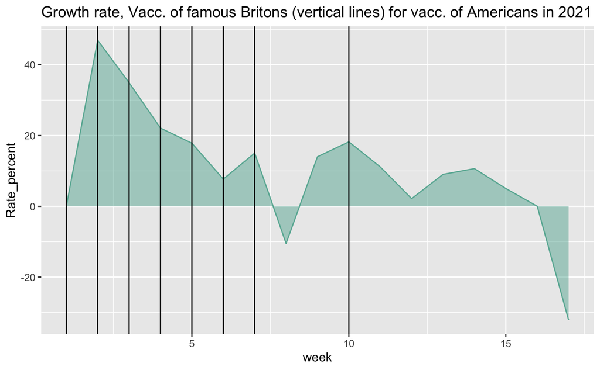

```r
p.growth_us.weekly <- growth_rate_us.weekly %>%
  ggplot( aes(x=week, y=Rate_percent)) +
    geom_area(fill="#69b3a2", alpha=0.5) +
    geom_line(color="#69b3a2") +
    geom_vline(xintercept = famous_british_vaccinated$week) +
    ggtitle("Growth rate, Vacc. of famous Britons (vertical lines) for vacc. of Americans in 2021")

p.growth_us.weekly
```

### Plotting growth rates for Britain and famous Americans (daily)

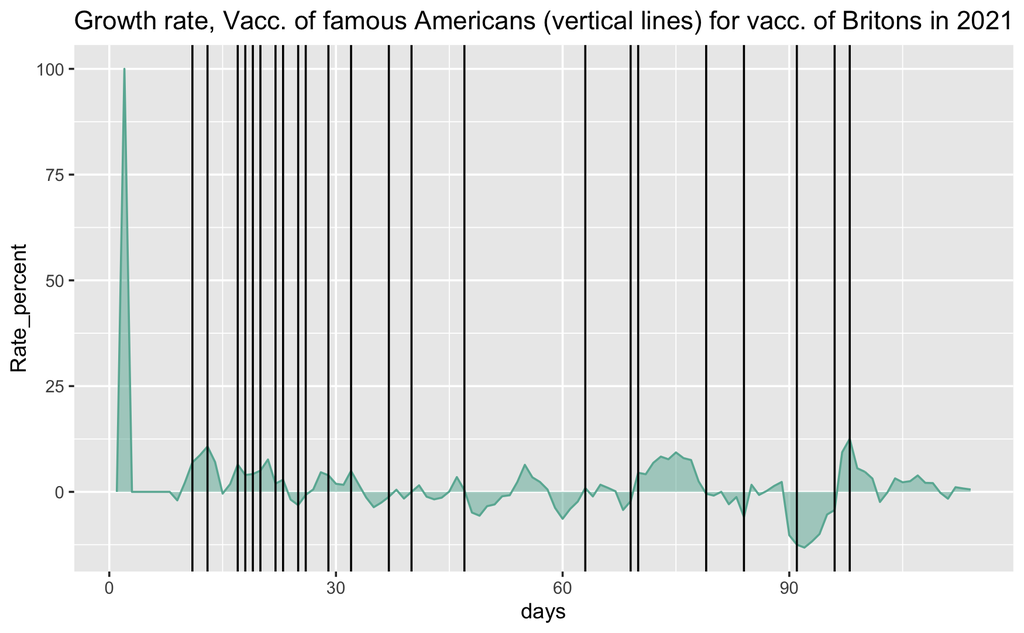

```r
p.growth_british.daily <- growth_rate_british.daily %>%
  ggplot( aes(x=days, y=Rate_percent)) +
    geom_area(fill="#69b3a2", alpha=0.5) +
    geom_line(color="#69b3a2") +
    geom_vline(xintercept = famous_us_vaccinated$days) +
    ggtitle("Growth rate, Vacc. of famous Americans (vertical lines) for vacc. of Britons in 2021")

p.growth_british.daily
```

### Plotting growth rates for the US and famous Britons (daily)

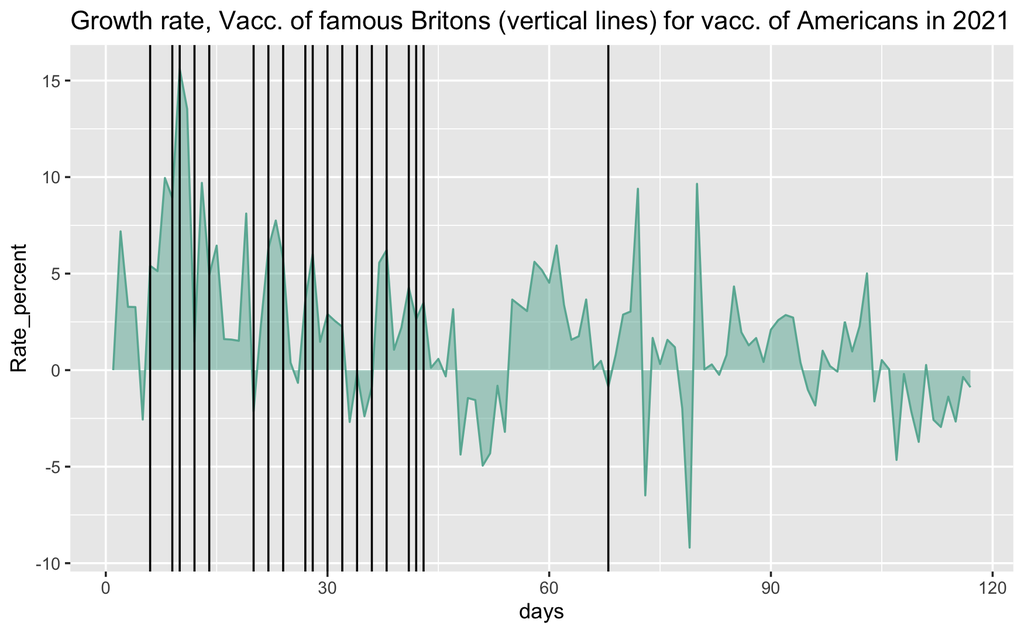

```r
p.growth_us.daily <- growth_rate_us.daily %>%
  ggplot( aes(x=days, y=Rate_percent)) +
    geom_area(fill="#69b3a2", alpha=0.5) +
    geom_line(color="#69b3a2") +
    geom_vline(xintercept = famous_british_vaccinated$days) +
    ggtitle("Growth rate, Vacc. of famous Britons (vertical lines) for vacc. of Americans in 2021")

p.growth_us.daily
```

#### Merge part

```r
merged.us.uk <- merge(growth_rate_british.daily, growth_rate_us.daily[, c("days", "Rate_percent"), ], by = "days")

merged.us.uk <- merged.us.uk %>%
  rename(
    Rate_percent.uk = Rate_percent.x,
    Rate_percent.us = Rate_percent.y
    )
merged.us.uk$daily_vaccinations_per_million <- NULL
merged.us.uk$Diff_day <- NULL
merged.us.uk$Diff_growth <- NULL

merged.us.uk
```

| days | date | Rate_percent.uk | Rate_percent.us |
| --- | --- | --- | --- |
| 1 | 2021-01-03 | 0.00000000 | 0.00000000 |
| 2 | 2021-01-04 | 100.00000000 | 7.18685832 |
| 3 | 2021-01-05 | 0.00000000 | 3.27706058 |
| 4 | 2021-01-06 | 0.00000000 | 3.26609030 |
| 5 | 2021-01-07 | 0.00000000 | -2.56157635 |
| 6 | 2021-01-08 | 0.00000000 | 5.40540541 |
| 7 | 2021-01-09 | 0.00000000 | 5.12820513 |
| 8 | 2021-01-10 | 0.00000000 | 9.95222930 |
| 9 | 2021-01-11 | -2.00916461 | 8.91950689 |
| 10 | 2021-01-12 | 2.17241379 | 15.60587515 |

[output cut: 104 more lines]

#### Cross-correlation between British and US vaccination data

And as you can see, when the lag varies around -8, then the value becomes significant in a positive correlation. But it is still very small ( < 0.3 ). Therefore, we can assume that there is a minimal positive correlation at a shift of about -8.

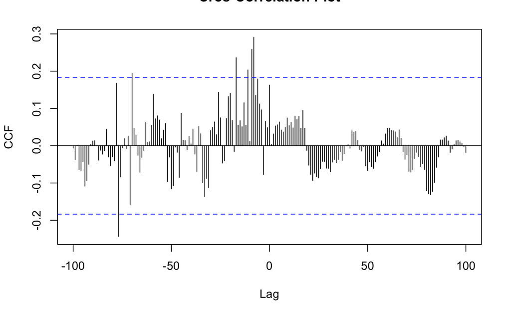

```r
# ccf time series
par(mfrow=c(1,1))
ccf(merged.us.uk[, c("Rate_percent.uk")], merged.us.uk[, c("Rate_percent.us")],
    lag.max = 100,
    main = "Cros-Correlation Plot",
    ylab = "CCF")
```

Now to calculate whether there is a correlation between celebrity vaccination and vaccination rates. First, move our day counter when the celebrity was vaccinated to the is_famous column by one. After all, if a celebrity was vaccinated at time `t`, then we at least need to know whether there is a correlation at time `t + 1` and so on.

```r
famous_british_vaccinated$is_famous <- 1

merged.us_vacc.uk_people <- merge(growth_rate_us.daily[, c("days", "Rate_percent"), ], famous_british_vaccinated[, c("days", "is_famous"), ], all = TRUE)

merged.us_vacc.uk_people <- merged.us_vacc.uk_people  %>%
  mutate(across(where(is.numeric), ~ ifelse(is.na(.), 0, .)))

temp <- setDF(lapply(merged.us_vacc.uk_people, function(x) shift(x, type = 'lag', fill = x[1L])))[]
merged.us_vacc.uk_people$is_famous_shifted <- temp$is_famous
merged.us_vacc.uk_people
```

| days | Rate_percent | is_famous | is_famous_shifted |
| --- | --- | --- | --- |
| 1 | 0.00000000 | 0 | 0 |
| 2 | 7.18685832 | 0 | 0 |
| 3 | 3.27706058 | 0 | 0 |
| 4 | 3.26609030 | 0 | 0 |
| 5 | -2.56157635 | 0 | 0 |
| 6 | 5.40540541 | 1 | 0 |
| 7 | 5.12820513 | 0 | 1 |
| 8 | 9.95222930 | 0 | 0 |
| 9 | 8.91950689 | 1 | 0 |
| 10 | 15.60587515 | 1 | 1 |

[output cut: 107 more lines]

We will now cross-correlate our data. We will be interested only in a positive lag. After all, a negative lag will show a correlation in the past, and this does not make sense.

And how can we see that the correlation is present from the beginning of the celebrity vaccination announcement until the 33nd day from that moment. But again, this positive correlation is so minimal `(~0.2 < x < 0.3)` that it barely exceeds the line of significance. But this result is obvious, because the correlation between Britain and the United States is not really obvious. Perhaps, if you choose the best countries at a similar rate of vaccination, they will show a clearer result. And yes, the growth rate of vaccination of famous Britons has a vague positive correlation.

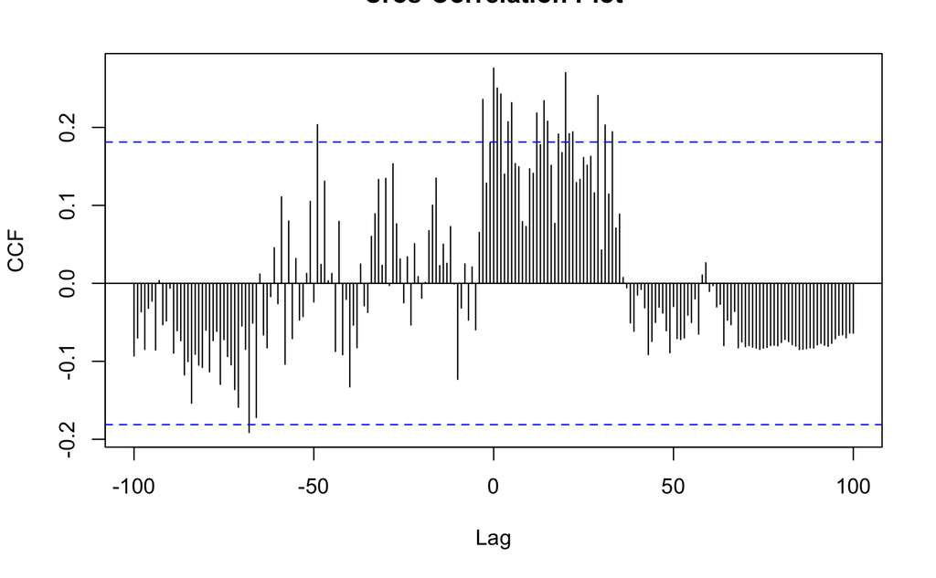

```r
# ccf time series
par(mfrow=c(1,1))
ccf(merged.us_vacc.uk_people$is_famous_shifted, merged.us_vacc.uk_people$Rate_percent,
    lag.max = 100,
    main = "Cros-Correlation Plot",
    ylab = "CCF")
```

### Now let’s repeat the same test, only for American celebrities and the British growth rate of vaccination

```r
famous_us_vaccinated$is_famous <- 1

merged.uk_vacc.us_people <- merge(growth_rate_british.daily[, c("days", "Rate_percent"), ], famous_us_vaccinated[, c("days", "is_famous"), ], all = TRUE)

merged.uk_vacc.us_people <- merged.uk_vacc.us_people  %>%
  mutate(across(where(is.numeric), ~ ifelse(is.na(.), 0, .)))

temp <- setDF(lapply(merged.uk_vacc.us_people, function(x) shift(x, type = 'lag', fill = x[1L])))[]
merged.uk_vacc.us_people$is_famous_shifted <- temp$is_famous
merged.uk_vacc.us_people
```

| days | Rate_percent | is_famous | is_famous_shifted |
| --- | --- | --- | --- |
| 1 | 0.00000000 | 0 | 0 |
| 2 | 100.00000000 | 0 | 0 |
| 3 | 0.00000000 | 0 | 0 |
| 4 | 0.00000000 | 0 | 0 |
| 5 | 0.00000000 | 0 | 0 |
| 6 | 0.00000000 | 0 | 0 |
| 7 | 0.00000000 | 0 | 0 |
| 8 | 0.00000000 | 0 | 0 |
| 9 | -2.00916461 | 0 | 0 |
| 10 | 2.17241379 | 0 | 0 |

[output cut: 104 more lines]

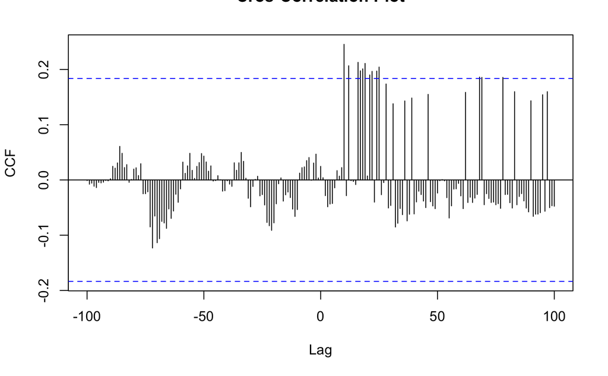

```r
# ccf time series
par(mfrow=c(1,1))
ccf(merged.uk_vacc.us_people$is_famous_shifted, merged.uk_vacc.us_people$Rate_percent,
    lag.max = 100,
    main = "Cros-Correlation Plot",
    ylab = "CCF")
```